# Group 9 - Predicting CCRB Dispositions: Analyzing Substantiated and Exonerated Allegations in NYPD Data (1985–2020)

# Instructions

You and your team of data scientists were hired by a company to gain insights on the dataset in your chosen prompt.

1. Perform any necessary data pre-processing and cleaning, and document your steps. Depending on the prompt you selected, this may involve transforming variables, creating new variables, and merging data frames. In particular, you may need to make some decisions on how to handle missing data, such as removing rows or columns with a significant amount of missing observations, creating an “unknown” category, or replacing/imputing the missing values. You do not need to develop a rigorous process or cite references, but please briefly justify your choices.
2. Make and interpret 4-10 visualizations to help you understand the relationships between the variables in your dataset. We highly encourage you to explore the data on your own, but when preparing your response to this question, please be parsimonious in your plots and select visualizations that help you tell a story about the data. If you need to make additional plots to support your responses to the other questions (e.g. to motivate data cleaning or modeling choices), that’s fine.
3. Build any 2 machine learning models that use your choice of covariates to predict the given outcome variable. Explain why you chose those covariates and interpret the model performances. If you are including categorical variables as covariates in a `glmnet` model (lasso or ridge regression), please remember that you will need to convert your covariate data frame into a *model matrix*, e.g. by calling the `model.matrix` function:

```r
model_matrix = model.matrix(~.-1, my_covariate_df)
```

4. The company stakeholders want to know what decision they should make on their stated goal/question. Based on your analysis, make recommendations for a non-technical audience.
5. Any additional information that might be useful to collect/have? Other open-ended/non-coding question(s)?

### NYPD complaints

The file `allegations_202007271729.csv` contains records about closed cases for every police officer on the NYPD force as of late June 2020 who had at least one substantiated allegation against them, spanning from September 1985 to January 2020. Information on the variables in this dataset can be found in `CCRB Data Layout Table.xlsx`. This data was downloaded from [Kaggle](https://www.kaggle.com/datasets/mrmorj/civilian-complaints-against-nyc-police-officers) and originally reported on by ProPublica. Your goal is to recommend a model to predict the disposition ruled by the Civilian Complaint Review Board (CCRB) and identify key variables that appear to be associated with the board’s ruling.

Please restrict your analysis to observations that were either “Substantiated” or “Exonerated”, excluding observations that were “Unsubstantiated”. This means that your models should predict whether the CCRB determined that the officer violated NYPD rules (yes = Substantiated, no = Exonerated), excluding cases where the CCRB could not conclude if the conduct occurred (Unsubstantiated). If you choose to incorporate information on officer rank and command, you will most likely want to collapse or otherwise simplify the categories for these variables (see the Rank Abbrevs and Command Abbrevs tabs in `CCRB Data Layout Table.xlsx`). If you do so, please briefly justify your reasoning.

```r
######***ANALYSIS PLAN***######
##GOAL: Recommend a model to predict the disposition ruled by the Civilian Complaint Review Board (CCRB) and identify key variables that appear to be associated with the board's ruling.

##POSSIBLE COVARIATES:
  ##Mos demographic: mos_ethnicity, mos_gender, mos_age_incident
  ##Complainant demographic: complainant_ethnicity, complainant_gender, complainant_age_incident
  ##Complaint: fado_type, allegation
  ##month_received, year_received
  ##command_at_incident, rank_incident, precinct

##PURPOSE OF THE VIRTUALIZATION: distribution of outcomes, exploring relationships between variables, and identifying patterns

#Table 1. Characteristics summary across the disposition
```

```r
# to do list
# 0. do exclusion first -- "restrict your analysis to observations that were either "Substantiated" or "Exonerated", excluding observations that were "Unsubstantiated
# 1. data cleaning and write down notes about why
  # 1.1. exclude missing rows or combines missing as unknown categories
  # 1.2. merge categories or derive new variables if needed
# 4. make 4-10 plots/tables about data
# 5. Build any 2 machine learning models that use your choice of covariates to predict the given outcome variable.
# 6. Explain why you chose those covariates and interpret the model performances.
# 7. Make recommendations for a non-technical audience./ your models should predict whether the CCRB determined that the officer violated NYPD rules
```

# Part I: Data cleaning

## Outcome:

```r
# Excluding observations that were "Unsubstantiated"
df1 <- df %>% filter(!board_disposition %in% c("Unsubstantiated"))

# Derive Outcome Variable: Exonerated = 0; Substantiated = 1
table(df1$board_disposition, useNA = "ifany")
```

```
##
##                               Exonerated
##                                     9609
##                  Substantiated (Charges)
##                                     3796
##     Substantiated (Command Discipline A)
##                                      964
##     Substantiated (Command Discipline B)
##                                      789
##       Substantiated (Command Discipline)
##                                      851
## Substantiated (Command Lvl Instructions)
##                                      454
##      Substantiated (Formalized Training)
##                                     1033
##             Substantiated (Instructions)
##                                      248
##         Substantiated (MOS Unidentified)
##                                        1
##       Substantiated (No Recommendations)
##                                      165
```

```r
df1$outcome <- 1
df1$outcome[df1$board_disposition == "Exonerated"] <- 0
table(df1$outcome)
```

```
##
##    0    1
## 9609 8301
```

## Covariates:

### Exclude covariates that will not be used:

```r
df2 <- df1 %>% select(-c(first_name, last_name,
                         command_now, rank_abbrev_now, rank_now,
                         rank_abbrev_incident,
                         month_closed, year_closed,
                         board_disposition))

#"first_name" + "last_name": not use the name of the officers
#"command_now" + "rank_abbrev_now" + "rank_now": Variables contains 'now' was excluded. Since we will not the variable after the outcome to predict outcome
# "rank_abbrev_incident": We have another version of variable `rank_incident` which contains less categories. Less categories make sure each group have more people and the model will be more effeciency.
# "month_closed" + "year_closed were excluded since these are variables after the outcome
# "board_disposition" was excluded since this is the source variable to derive outcome
```

### Futher clean covariates:

#### complainant_ethnicity: refused + unknown into one group

```r
#combined missing, unknow, and refused
df2$complainant_ethnicity[df2$complainant_ethnicity == "Refused"] <- "Unknown"
df2$complainant_ethnicity[is.na(df2$complainant_ethnicity)] <- "Unknown"
table(df2$complainant_ethnicity)
```

```
##
## American Indian           Asian           Black        Hispanic      Other Race
##              40             304            8932            3261             340
##         Unknown           White
##            3559            1474
```

#### complainant_gender: trans + nonconforming + missing into one group

```r
df2$complainant_gender[df2$complainant_gender %in% c("Not described", "Transwoman (MTF)", "Gender non-conforming", "Transman (FTM)" )] <- "Other"
df2$complainant_gender[is.na(df2$complainant_gender)] <- "Other"
```

#### complainant_age_incident:-1; too many missing –> may drop this variate since there is too many missing

```r
df2$complainant_age_incident[df2$complainant_age_incident <= 0] <- NA
```

#### command_at_incident –> ‘cmd.category’ based on Command Abbrevs sheet with combination of some groups with too little people

```r
library(readxl)
cmd.abb <- readxl::read_xlsx("CCRB Data Layout Table.xlsx", sheet = "Command Abbrevs")

#cmd.abb
df2$command_at_incident.d <- NA
df2$command_at_incident.d <- cmd.abb$`Command Name`[match(df2$command_at_incident, cmd.abb$Abbreviation)]

data <- df2
data$Category <- NA
# Category 1: Precincts (Patrol Divisions)
data$Category[grep("Precinct", data$command_at_incident.d )] <- "Precincts"

# Category 2: Specialized Units/Divisions
specialized_units <- c("Narcotics", "Detective", "Gang", "Intelligence", "Emergency Service",
                       "Strategic Response", "Transportation", "Counterterrorism", "Vice", "Arson")
for (unit in specialized_units) {
  data$Category[grep(unit, data$command_at_incident.d )] <- "Specialized Units/Divisions"
}

# Category 3: Bureau/Command Divisions
bureau_units <- c("Internal Affairs Bureau", "Police Service Area", "Criminal Intelligence",
                  "Criminal Justice Bureau", "Patrol Borough", "Medical Division", "Staff Services")
for (bureau in bureau_units) {
  data$Category[grep(bureau, data$command_at_incident.d )] <- "Bureau/Command Divisions"
}

# Category 4: Miscellaneous/Other
miscellaneous <- c("Training", "Administration", "Facilities", "Operations", "Records", "Support")
for (misc in miscellaneous) {
  data$Category[grep(misc, data$command_at_incident.d )] <- "Miscellaneous/Other"
}

data$cmd.category <- data$Category
data$cmd.category[is.na(data$cmd.category)] <- "Unknown"
table(data$cmd.category)
```

```
##
##    Bureau/Command Divisions         Miscellaneous/Other
##                        1829                          51
##                   Precincts Specialized Units/Divisions
##                       11536                        2020
##                     Unknown
##                        2474
```

#### rank_incident –> ‘rank.cat’ based on Rank Abbrevs sheet with combination of some groups with too little people

```r
data <- data %>%
  mutate(rank.cat = case_when(
    str_detect(rank_incident, "Police Officer") ~ "Entry-Level",  # Police Officer
    str_detect(rank_incident, "Sergeant") ~ "Supervisory",        # Sergeant, Sergeant Special Assignment, Sergeant Detective Squad
    str_detect(rank_incident, "Detective") ~ "Detective",         # Detective Grades 1-3, Detective Specialist
    str_detect(rank_incident, "Lieutenant") ~ "Supervisory",      # Lieutenant, Lieutenant Special Assignment, Lieutenant Commander Detective
    str_detect(rank_incident, "Captain") ~ "Supervisory",         # Captain
    str_detect(rank_incident, "Chief") ~ "Supervisory",             # Chief roles
    str_detect(rank_incident, "Surgeon") ~ "Specialized Roles",   # Surgeon, Chief Surgeon, Deputy Chief Surgeon
    TRUE ~ "Other"
  ))

table(data$rank.cat)
```

```
##
##   Detective Entry-Level       Other Supervisory
##        1545       12280          63        4022
```

```r
# Entry-Level: Police Officer
# Supervisory: Sergeant, Lieutenant, Captain
# Detective: Detective Grades 1-3, Detective Specialist, Sergeant Detective Squad
# Executive: Chief roles (Chief of Department, Chief of Staff, etc.)
# Specialized Roles: Special Assignment and Surgeon titles
```

#### allegation –> ‘allegation.cat’ based on the common knowledge

```r
data <- data %>%
  mutate(allegation.cat = case_when(
    str_detect(allegation, "Arrest|Question|Detention|Search|Stop|Premises entered|Person Searched|Seizure of property") ~ "Police Actions",
    str_detect(allegation, "Chokehold|Gun as club|Handcuffs too tight|Pepper spray|Flashlight as club|Gun Drawn|Gun fired|Physical force|Mace|Punch/Kick|Push/Shove") ~ "Use of Force",
    str_detect(allegation, "Ethnicity|Race|Gender|Sexual orientation|Religion|Sex Miscon|Gay/Lesbian Slur|Sexist Remark|Sexual Humiliation|Gender Identity") ~ "Discrimination and Bias",
    str_detect(allegation, "Curse|Nasty Words|Profane Gesture|Rude Gesture|Other- Discourtesy|Retaliatory arrest|Retaliatory summons") ~ "Misconduct",
    str_detect(allegation, "Body Cavity Searches|Frisk|Flashlight as club|Forcible Removal to Hospital|Gun Drawn|Strip-searched") ~ "Searches and Seizures",
    str_detect(allegation, "Threat of force|Threat of arrest|Threat of force|Threat to Property|Threat to damage/seize property") ~ "Threats and Intimidation",
    str_detect(allegation, "Property damaged|Property Seized|Hit against inanimate object|Vehicle stop|Vehicle search") ~ "Property Damage",
    str_detect(allegation, "Electronic device information deletion|Improper dissemination of medical info|Failed to Obtain Language Interpretation|Refusal to obtain medical treatment|Refusal to provide RTKA card") ~ "Health and Medical Issues",
    TRUE ~ "Other"
  ))

table(data$allegation.cat, useNA="ifany")
```

```
##
##   Discrimination and Bias Health and Medical Issues                Misconduct
##                       108                        76                       459
##                     Other            Police Actions           Property Damage
##                      3777                      5104                      1793
##     Searches and Seizures  Threats and Intimidation              Use of Force
##                      1884                      1099                      3610
```

```r
# Police Actions: Actions related to arrests, questioning, detention, and other procedural activities.
# Use of Force: Physical actions or methods used by officers involving force, weapons, or restraints.
# Discrimination and Bias: Racial, ethnic, gender, and other biased behaviors.
# Misconduct: Includes verbal abuse, discourtesy, and violations of rules or conduct.
# Searches and Seizures: Activities involving searches of individuals, premises, or vehicles, as well as property seizures.
# Threats and Intimidation: Actions and language involving threats to individuals or property.
# Property Damage: Destruction, damage, or inappropriate use of property.
# Health and Medical Issues: Actions related to medical care, including refusals and improper practices.
# Other: Miscellaneous or unclassified items.
```

#### precinct –> ‘precinct_cat’ based on the specific precint form NYPD websites

```r
#table(data$precinct)

# https://www.nyc.gov/site/nypd/bureaus/patrol/precincts-landing.page

data$precinct_cat[data$precinct %in% c(1,5,6,7,9,10,13,14,17,18,19,20,22,23,24,25,26,28,30,32,33,34)] <- "Manhattan"
data$precinct_cat[data$precinct %in% c(40, 41, 42, 43, 44, 45, 46, 47, 48, 49, 50, 52)] <- "Bronx"

data$precinct_cat[data$precinct %in% c(60, 61, 62, 63, 66, 67, 68, 69, 70, 71, 72, 73, 75, 76, 77, 78, 79, 81, 83, 84, 88, 90, 94)] <- "Brooklyn"

data$precinct_cat[data$precinct %in% c(100, 101, 102, 103, 104, 105, 106, 107, 108, 109, 110, 111, 112, 113, 114, 115)] <- "Queens"

data$precinct_cat[data$precinct %in% c(120, 121, 122, 123)] <- "Staten Island"
data$precinct_cat[is.na(data$precinct)] <- "Unknown"
data$precinct_cat[data$precinct %in% c(0, 1000)] <- "Unknown"


table(data$precinct_cat, useNA = "ifany") # The missing is since the precinct is missing
```

```
##
##         Bronx      Brooklyn     Manhattan        Queens Staten Island
##          4379          6732          3356          2633           782
##       Unknown
##            28
```

```r
# Bronx      Brooklyn     Manhattan        Queens Staten Island       Unknown
```

#### contact_reason –> ‘contact_reason_cat’ based on the common knowledge

```r
df.contact <- data.frame(table(data$contact_reason))
write.csv(df.contact, "df_contact.csv")

data <- data %>%
  mutate(contact_reason_cat = case_when(
    contact_reason %in% c("Aided case", "EDP aided case", "EDP Aided Cases", "Execution of arrest/bench warrant",
                    "Execution of search warrant", "Report of Crime Past/Present", "Report of other crime",
                    "Report-gun possession/shots fired", "Report-possession/sale of narcotics", "Victim Subject of Sex Crime",
                    "PD suspected C/V of violation/crime - auto", "PD suspected C/V of violation/crime - bldg",
                    "PD suspected C/V of violation/crime - street", "PD suspected C/V of violation/crime - subway") ~ "Crime-Related Activities",

    contact_reason %in% c("C/V at PCT to file complaint of crime", "C/V at PCT to obtain information", "C/V at PCT to retrieve property",
                    "C/V intervened on behalf of/observed encounter w/3rd party", "C/V requested info from officer",
                    "C/V requested investigation of crime", "C/V telephoned PCT", "Complainant at Pct. to make a Cmpl/info",
                    "Telephone Call to Precinct/Command", "Summons/Complainant") ~ "Non-Crime Reports or Inquiries",

    contact_reason %in% c("Moving violation", "Other violation of VTL", "Parking violation", "Traffic accident",
                    "Traffic Incidents/Accident/Prk Violation", "Vehicle Stop and Check", "Transit checkpoint",
                    "PD auto checkpoint") ~ "Traffic and Parking Violations",

    contact_reason  %in% c("Dispute", "Demonstration/protest", "Demonstrations", "Report of Disturbance/Noise Complaint",
                    "Report-noise/disturbance", "Report-domestic dispute", "Report-dispute", "EDP Aided Cases") ~ "Disputes and Public Disturbances",

     contact_reason  %in% c("Assist ACS or other agency", "Complainant Witnessing Incident", "Patrol Encounter",
                    "Regulatory inspection", "Parade/special event", "No contact", "Others", "Other",
                    "Stop/Question/Frisk") ~ "Assistance and Public Service",

    TRUE ~ "Unknown"
  ))

table(data$contact_reason_cat, useNA = "ifany")
```

```
##
##    Assistance and Public Service         Crime-Related Activities
##                             2671                            10702
## Disputes and Public Disturbances   Non-Crime Reports or Inquiries
##                             1280                              812
##   Traffic and Parking Violations                          Unknown
##                             2243                              202
```

#### outcome_description –> ‘outcome_desc.cat’ based on the common knowledge

```r
# df.outcome <- data.frame(table(data$outcome_description))
# write.csv(df.outcome, file = "df_outcome_desc.csv")
data <- data %>%
  mutate(outcome_desc.cat = case_when(
    outcome_description %in% c("Arrest - assault (against a PO)", "Arrest - resisting arrest", "Assault/Arrested",
                    "Resisting Arrest/Arrested") ~ "Arrests for Violent/Physical Crimes",

    outcome_description %in% c("Arrest - disorderly conduct", "Arrest - harassment (against a PO)", "Arrest - OGA",
                    "Arrest on Other Charge", "Arrest - other violation/crime", "Obstruct-Govt-Admin/Arrested") ~ "Arrests for Non-Violent Crimes",

    outcome_description %in% c("Disorderly-Conduct/Arr/Summons", "Harassment/Arrested/Summons", "Summons - disorderly conduct",
                    "Summons - harassment (against a PO)", "Summons - OGA", "Summons - other violation/crime",
                    "Parking summons issued", "Moving violation summons issued", "Other VTL violation summons issued",
                    "Traffic Summons Claimed or Issued") ~ "Summonses (Non-Arrest Related)",

    outcome_description %in% c("Juvenile Report", "No arrest made or summons issued", "Other Summons Claimed or Issued") ~ "Juvenile and Other Reports",

    TRUE ~ "Unknown"
  ))

table(data$outcome_desc.cat)
```

```
##
##      Arrests for Non-Violent Crimes Arrests for Violent/Physical Crimes
##                                6203                                1413
##          Juvenile and Other Reports      Summonses (Non-Arrest Related)
##                                7095                                3152
##                             Unknown
##                                  47
```

```r
# Arrests for Violent/Physical Crimes: This category would include crimes related to violence or physical confrontation with law enforcement officers or others.
# Arrests for Non-Violent Crimes: These are arrests related to non-violent offenses or non-compliance.
# Summonses (Non-Arrest Related): This category includes summons issued for offenses that don't result in arrest but require official action, such as a ticket or citation.
# Juvenile and Other Reports: This category would include reports related to juveniles or non-specific incidents where an arrest or summons is not involved.
```

## Extract variables to be used

```r
df.cleaned <- data %>% select(-c(precinct, allegation, command_at_incident.d, Category, contact_reason, outcome_description, command_at_incident, rank_incident))

names(df.cleaned)
```

```
##  [1] "unique_mos_id"            "shield_no"
##  [3] "complaint_id"             "month_received"
##  [5] "year_received"            "mos_ethnicity"
##  [7] "mos_gender"               "mos_age_incident"
##  [9] "complainant_ethnicity"    "complainant_gender"
## [11] "complainant_age_incident" "fado_type"
## [13] "outcome"                  "cmd.category"
## [15] "rank.cat"                 "allegation.cat"
## [17] "precinct_cat"             "contact_reason_cat"
## [19] "outcome_desc.cat"
```

*Data Pre-processing and Cleaning: Outcome Variable* *In the data cleaning stage of the project, we focused on observations where the board’s decisions were clear, specifically those labeled as “Substantiated” or “Exonerated.” To do this, we filtered out any cases marked as “Unsubstantiated.” Next, we prepared the outcome variable by assigning a value of 0 to “Exonerated” cases and a value of 1 to “Substantiated” cases. This step created a straightforward binary variable that distinguishes between the two types of board decisions, setting the stage for our upcoming analysis.*#

*Data Pre-processing and Cleaning: Covariates I* *In the initial phase of cleaning our covariates, we selected relevant variables by excluding those not necessary for our analysis. We removed personal identifiers such as `first_name` and `last_name` because they do not contribute to predicting the outcomes of the cases. Variables related to the current status of officers, such as `command_now`, `rank_abbrev_now`, and `rank_now`, were also excluded because our focus is on conditions at the time of the incident, not their present status.* #*Additionally, we opted to use `rank_incident` over `rank_abbrev_incident` because it contains fewer categories, which simplifies our model and improves its efficiency by ensuring a larger sample size in each category. Variables indicating the time of case closure like `month_closed` and `year_closed` were removed as they occur after the outcome and could lead to data leakage, influencing the model with information that wouldn’t be available at the time of prediction. Lastly, `board_disposition` was excluded as it was the basis for deriving our outcome variable, making it redundant for further modeling.*

# Part II: Data Visualization

## Table

### Table 1: Descriptive

```r
table1_list <- c(
  "month_received", "year_received",
  "mos_ethnicity", "mos_gender", "mos_age_incident",
  "cmd.category", "rank.cat",
  "complainant_ethnicity", "complainant_gender", "complainant_age_incident",
  "fado_type",  "allegation.cat", "precinct_cat", "contact_reason_cat", "outcome_desc.cat"
)
cat_var <- c(
  "month_received", "year_received",
  "mos_ethnicity", "mos_gender",
  "complainant_ethnicity", "complainant_gender",
  "fado_type", "cmd.category", "rank.cat", "allegation.cat", "precinct_cat", "contact_reason_cat", "outcome_desc.cat"
)
df.cleaned
```

```
## # A tibble: 17,910 × 19
##    unique_mos_id shield_no complaint_id month_received year_received
##            <dbl>     <dbl>        <dbl>          <dbl>         <dbl>
##  1         10004      8409        42835              7          2019
##  2         10007      5952        24601             11          2011
##  3         10007      5952        24601             11          2011
##  4         10007      5952        26146              7          2012
##  5         10009     24058        40253              8          2018
##  6         10012      4021        37256              5          2017
##  7         10014      4143        33969             11          2015
##  8         10017     15187        41927              3          2019
##  9         10018      4518        36984              4          2017
## 10         10026      3185        27482              3          2013
## # ℹ 17,900 more rows
## # ℹ 14 more variables: mos_ethnicity <chr>, mos_gender <chr>,
## #   mos_age_incident <dbl>, complainant_ethnicity <chr>,
## #   complainant_gender <chr>, complainant_age_incident <dbl>, fado_type <chr>,
## #   outcome <dbl>, cmd.category <chr>, rank.cat <chr>, allegation.cat <chr>,
## #   precinct_cat <chr>, contact_reason_cat <chr>, outcome_desc.cat <chr>
```

```r
df.cleaned[cat_var] <- lapply(df.cleaned[cat_var], as.factor)

#month_received
table1::label(df.cleaned$month_received) <- "Month receive the complaint"
#year_received
table1::label(df.cleaned$year_received) <- "Year receive the complaint"
#mos_ethnicity
table1::label(df.cleaned$mos_ethnicity) <- "Ethnicity (Mos)"
#mos_gender
# df.cleaned$mos_gender <- factor(
#   df.cleaned$mos_gender,
#   level = c("F", "M"),
#   labels = c("Female", "Male")
# )
df.cleaned$mos_gender <- ifelse(df.cleaned$mos_gender == "M", "Male", "Female")
table1::label(df.cleaned$mos_gender) <- "Gender (Mos)"
#mos_age_incident
table1::label(df.cleaned$mos_age_incident) <- "Age ate incident (Mos)"
#cmd.category
table1::label(df.cleaned$cmd.category) <- "Officer's command at the incident"
#rank.cat
table1::label(df.cleaned$rank.cat) <- "Officer's rank at the incident"
#complainant_ethnicity
table1::label(df.cleaned$complainant_ethnicity) <- "Ethnicity (Complainant)"
#complainant_gender
table1::label(df.cleaned$complainant_gender) <- "Gender (Complainant)"
#complainant_age_incident
table1::label(df.cleaned$complainant_age_incident) <- "Age ate incident (Complainant)"
#fado_type
table1::label(df.cleaned$fado_type) <- "Top-level category of complaint"
#allegation.cat
table1::label(df.cleaned$allegation.cat) <- "Specific category of complaint"
#precinct_cat
table1::label(df.cleaned$precinct_cat) <- "Precinct of the complaint"
#contact_reason_cat
table1::label(df.cleaned$contact_reason_cat) <- "Reason of the complaint"
#outcome_desc.cat
table1::label(df.cleaned$outcome_desc.cat) <- "Outcome of the complaint contact"
#outcome
df.cleaned$outcome <- factor(
  df.cleaned$outcome,
  levels = c(0, 1),
  labels = c("Exonerated", "Substantiated")
)
table1::label(df.cleaned$outcome) <- "Outcome of the complaint contact"

table1::table1(
  as.formula(paste("~", paste(table1_list, collapse = "+"), "| outcome")),
  data = df.cleaned
)
```

|  | Exonerated (N=9609) | Substantiated (N=8301) | Overall (N=17910) |
| --- | --- | --- | --- |
| Month receive the complaint |  |  |  |
| 1 | 757 (7.9%) | 693 (8.3%) | 1450 (8.1%) |
| 2 | 785 (8.2%) | 720 (8.7%) | 1505 (8.4%) |
| 3 | 921 (9.6%) | 825 (9.9%) | 1746 (9.7%) |
| 4 | 867 (9.0%) | 697 (8.4%) | 1564 (8.7%) |
| 5 | 811 (8.4%) | 736 (8.9%) | 1547 (8.6%) |
| 6 | 832 (8.7%) | 693 (8.3%) | 1525 (8.5%) |
| 7 | 843 (8.8%) | 606 (7.3%) | 1449 (8.1%) |
| 8 | 881 (9.2%) | 784 (9.4%) | 1665 (9.3%) |
| 9 | 818 (8.5%) | 690 (8.3%) | 1508 (8.4%) |
| 10 | 774 (8.1%) | 717 (8.6%) | 1491 (8.3%) |
| 11 | 687 (7.1%) | 578 (7.0%) | 1265 (7.1%) |
| 12 | 633 (6.6%) | 562 (6.8%) | 1195 (6.7%) |
| Year receive the complaint |  |  |  |
| 1985 | 0 (0%) | 1 (0.0%) | 1 (0.0%) |
| 1986 | 3 (0.0%) | 3 (0.0%) | 6 (0.0%) |
| 1987 | 1 (0.0%) | 1 (0.0%) | 2 (0.0%) |
| 1988 | 0 (0%) | 10 (0.1%) | 10 (0.1%) |
| 1989 | 2 (0.0%) | 2 (0.0%) | 4 (0.0%) |
| 1990 | 4 (0.0%) | 14 (0.2%) | 18 (0.1%) |
| 1991 | 8 (0.1%) | 5 (0.1%) | 13 (0.1%) |
| 1992 | 1 (0.0%) | 22 (0.3%) | 23 (0.1%) |
| 1993 | 6 (0.1%) | 22 (0.3%) | 28 (0.2%) |
| 1994 | 20 (0.2%) | 57 (0.7%) | 77 (0.4%) |
| 1995 | 34 (0.4%) | 62 (0.7%) | 96 (0.5%) |
| 1996 | 42 (0.4%) | 79 (1.0%) | 121 (0.7%) |
| 1997 | 49 (0.5%) | 62 (0.7%) | 111 (0.6%) |
| 1998 | 58 (0.6%) | 78 (0.9%) | 136 (0.8%) |
| 1999 | 68 (0.7%) | 27 (0.3%) | 95 (0.5%) |
| 2000 | 85 (0.9%) | 69 (0.8%) | 154 (0.9%) |

[output cut: 94 more lines]

```r
df.cleaned$outcome <- as.character(df.cleaned$outcome)
df.cleaned$outcome[df.cleaned$outcome == "Substantiated"] = 1
df.cleaned$outcome[df.cleaned$outcome == "Exonerated"] = 0
df.cleaned$year_received <- as.numeric(as.character(df.cleaned$year_received))
df.cleaned$year_month <- paste0(df.cleaned$year_received, "-", sprintf("%02d", df.cleaned$month_received))
df.cleaned <- df.cleaned %>%
  mutate(year_month = as.Date(paste0(year_month, "-01"), format = "%Y-%m-%d"))
```

## Figure: Data Visualization

### Figure 1: Stacked Bar Plot - Distribution of Outcomes by Complainant Age

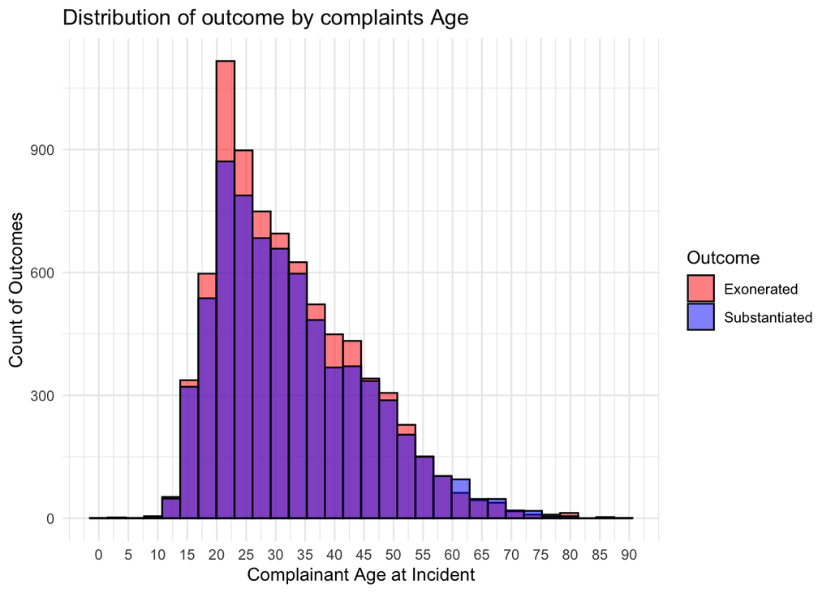

```r
plot.complainant_age_incident <- df.cleaned %>%
  ggplot(
  aes(x = complainant_age_incident, fill = factor(outcome))) +
  geom_histogram(alpha = 0.5, position = "identity", bins = 30, color = "black") +
  labs(title = "Distribution of outcome by complaints Age",
       x = "Complainant Age at Incident",
       y = "Count of Outcomes",
       fill = "Outcome") +
  theme_minimal() +
  scale_fill_manual(values = c("red", "blue") ,
                      labels = c("0" = "Exonerated", "1" = "Substantiated")
        ) +
  scale_x_continuous(breaks = seq(0, max(df.cleaned$complainant_age_incident, na.rm = T), by = 5))
plot.complainant_age_incident
```

### Figure 2: Time Series Line Plot - Trends of CCRB Complaint Outcomes by Command Categories Over Complaint Received Time

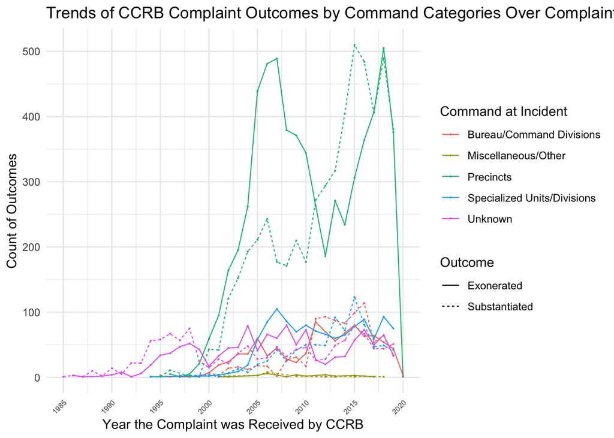

```r
df.plot.cmd.category <- df.cleaned %>%
  group_by(cmd.category, outcome, year_received) %>%
  summarize(Count = n(), .groups = "drop")

plot.cmd.category <- df.plot.cmd.category %>%
  ggplot(
    aes(x = year_received, y = Count, color = cmd.category, linetype = factor(outcome, labels = c("0" = "Exonerated", "1" = "Substantiated")))) +
  theme_minimal() +
  geom_line(size = 0.4) +
  geom_point(size = 0.1) +
  labs(title = "Trends of CCRB Complaint Outcomes by Command Categories Over Complaint Received Time",
       x = "Year the Complaint was Received by CCRB",
       y = "Count of Outcomes",
       color = "Command at Incident",
       linetype = "Outcome") +
   scale_x_continuous(breaks = seq(0, max(df.plot.cmd.category$year_received, na.rm = T), by = 5))+
  theme(axis.text.x = element_text(angle = 45, hjust = 1, size = 6))
plot.cmd.category
```

*Based on the plot showing the complaint outcomes by command categories over time, it suggests significant variations and overlaps in complaint outcomes across different command categories, indicating that Command at Incident may not serve as a reliable predictor for the CCRB dispositions. The inconsistencies across time and the overlapping trends for substantiated and not substantiated outcomes across commands suggest that the command at incident alone does not decisively influence the likelihood of a complaint being substantiated.*

### Figure 3: Time Series Line Plot - Trends of Outcomes Over Complaint Received Time

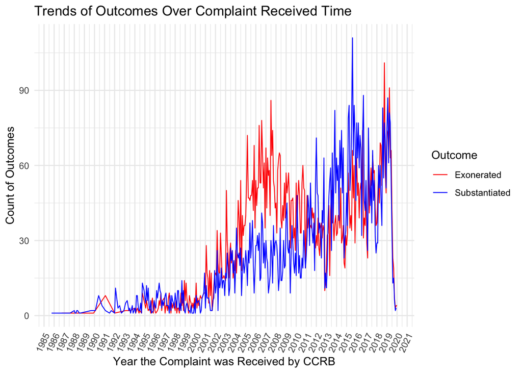

```r
Figure1 <- df.cleaned %>%
group_by(year_month, outcome) %>%
summarise(count = n()) %>%
ungroup()
Figure1$year_month <- as.Date(paste0(Figure1$year_month, "-01"))

ggplot(Figure1, aes(x = year_month, y = count, color = as.factor(outcome))) +
  geom_line(size = 0.4) +
  labs(title = "Trends of Outcomes Over Complaint Received Time",
       x = "Year the Complaint was Received by CCRB",
       y = "Count of Outcomes",
       color = "Outcome") +
  scale_x_date(date_labels = "%Y",
               date_breaks = "1 year") +
  scale_color_manual(values = c("0" = "red", "1" = "blue"),
                     labels = c("0" = "Exonerated", "1" = "Substantiated")) +
  theme_minimal() +
  theme(axis.text.x = element_text(angle = 65, hjust = 1))
```

### Figure 4: Grouped Bar Plot - Distribution of Outcomes by Complaint Received Time and FADO Type

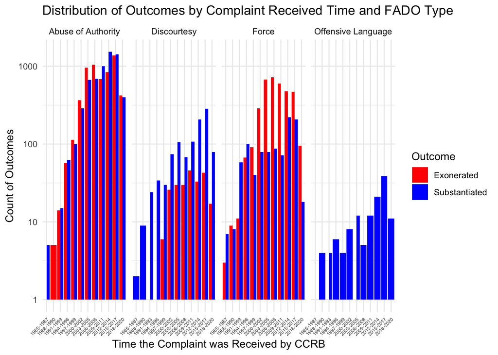

```r
Figure2 <- df.cleaned %>%
  group_by(
    three_year_group = cut(as.numeric(format(as.Date(paste0(year_month, "-01")), "%Y")),
                           breaks = seq(1985, 2021, by = 3),
                           labels = paste0(seq(1985, 2018, by = 3), "-", seq(1987, 2020, by = 3)),
                           include.lowest = TRUE),
    fado_type,
    outcome) %>% summarise(count = n(), .groups = "drop")

ggplot(Figure2, aes(x = three_year_group, y = count, fill = as.factor(outcome))) +
  geom_bar(stat = "identity", position = "dodge") +
  facet_grid(~fado_type) +
  labs(title = "Distribution of Outcomes by Complaint Received Time and FADO Type",
       x = "Time the Complaint was Received by CCRB",
       y = "Count of Outcomes",
       fill = "Outcome") +
  scale_fill_manual(values = c("0" = "red", "1" = "blue"),
                    labels = c("0" = "Exonerated", "1" = "Substantiated")) +
  scale_y_log10() +
  theme_minimal() +
  theme(axis.text.x = element_text(angle = 45, hjust = 1, size = 5))
```

*The plot suggest a significant association between the outcome (substantiated vs. exonerated), FADO type, and time. In the bar plot, we see that certain FADO types, such as Force and Abuse of Authority, consistently have higher counts of complaints but show distinct differences in outcomes. For example, Force complaints are more likely to result in “Exonerated” outcomes, while Offensive Language complaints almost exclusively lead to “Substantiated” outcomes. This pattern indicates that the type of complaint strongly influences the likelihood of substantiation. Additionally, the trends over time show that the number of complaints has increased, particularly for “Abuse of Authority” and “Force”. While time plays a role in overall complaint volume, the association between outcomes and FADO type remains clear and consistent, showing that some complaint categories are more likely to be substantiated than others.*

### Figure 5: Faceted Line Graph - Trends of Outcomes Over Complaint Received Time by Precinct Category (exclude unknown precincts)

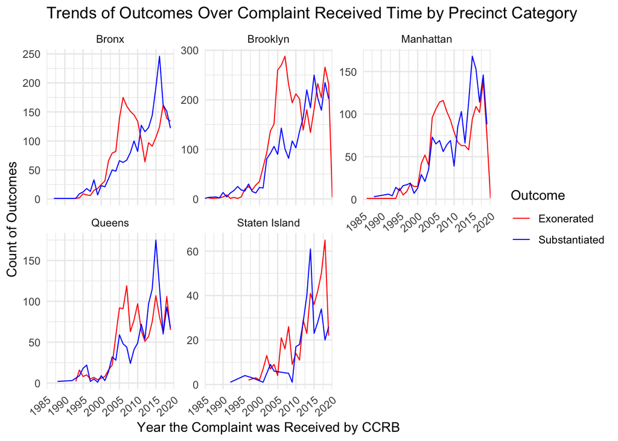

```r
Figure3 <- df.cleaned %>%
  filter(precinct_cat != "Unknown") %>%
  group_by(year_received, precinct_cat, outcome) %>%
  summarise(count = n(), .groups = "drop")

ggplot(Figure3, aes(x = year_received, y = count, color = as.factor(outcome), group = outcome)) +
  geom_line(size = 0.4) +
  facet_wrap(~precinct_cat, scales = "free_y") +
  labs(title = "Trends of Outcomes Over Complaint Received Time by Precinct Category",
       x = "Year the Complaint was Received by CCRB",
       y = "Count of Outcomes",
       color = "Outcome") +
  scale_color_manual(values = c("0" = "red", "1" = "blue"),
                     labels = c("0" = "Exonerated", "1" = "Substantiated")) +
  scale_x_continuous(breaks = seq(1985, 2021, by = 5),
                     expand = c(0, 0)) +
  theme_minimal() +
  theme(axis.text.x = element_text(angle = 40, hjust = 1))
```

### Figure 6: Time Series Line Plot - Outcomes by FADO Type Over Time

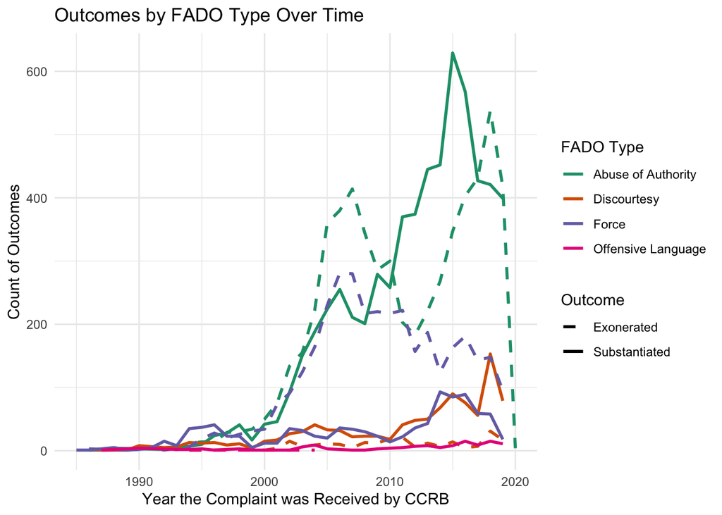

```r
df.cleaned %>%
  group_by(year_received, fado_type, outcome) %>%
  summarise(count = n(), .groups = "drop") %>%
  ggplot(aes(x = year_received, y = count, color = fado_type, linetype =
                        as.factor(outcome))) +
  geom_line(size = 1) +
  labs(
    title = "Outcomes by FADO Type Over Time",
    x = "Year the Complaint was Received by CCRB",
    y = "Count of Outcomes",
    color = "FADO Type",
    linetype = "Outcome"
  ) +
  scale_color_brewer(palette = "Dark2") +
  scale_linetype_manual(
    values = c("0" = "dashed", "1" = "solid"),
    labels = c("0" = "Exonerated", "1" = "Substantiated")
  ) +
  theme_minimal()
```

### Figure 7: Time Series Line Plot - Outcomes by Allegation Cat Over Time

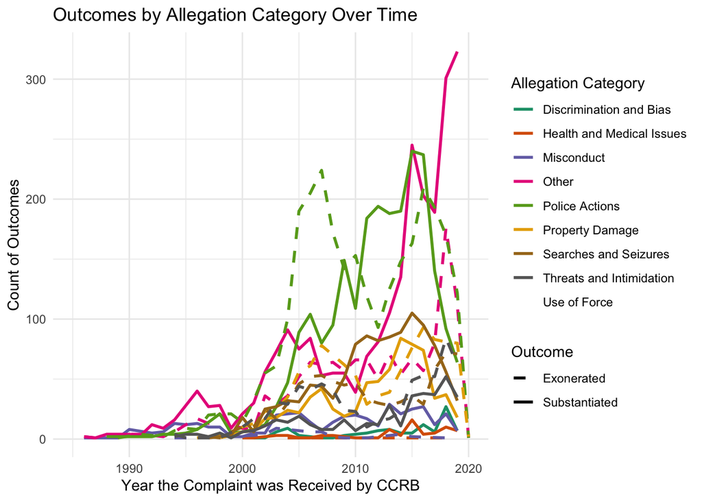

```r
df.cleaned %>%
  group_by(year_received, allegation.cat, outcome) %>%
  summarise(count = n(), .groups = "drop") %>%
  ggplot(aes(x = year_received, y = count, color = allegation.cat, linetype =
                        as.factor(outcome))) +
  geom_line(size = 1) +
  labs(
    title = "Outcomes by Allegation Category Over Time",
    x = "Year the Complaint was Received by CCRB",
    y = "Count of Outcomes",
    color = "Allegation Category",
    linetype = "Outcome"
  ) +
  scale_color_brewer(palette = "Dark2") +
  scale_linetype_manual(
    values = c("0" = "dashed", "1" = "solid"),
    labels = c("0" = "Exonerated", "1" = "Substantiated")
  ) +
  theme_minimal()
```

### Figure 8: Stacked Bar Plot - Distribution of Outcomes by Contact Reason, Complainant Ethnicity, and Outcome

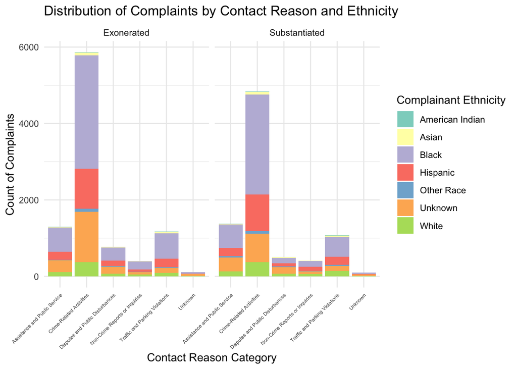

```r
reason_ethnicity <- df.cleaned %>%
  group_by(contact_reason_cat, complainant_ethnicity, outcome) %>% # group contact reason to figure out association
  summarise(count = n(), .groups = "drop")

# Plot the chart
ggplot(reason_ethnicity, aes(x = contact_reason_cat, y = count, fill = complainant_ethnicity)) + # add in relative x and y axis
  geom_bar(stat = "identity", position = "stack") +  # Stacked bars
  facet_wrap(~outcome, ncol = 2, labeller = as_labeller(c("0" = "Exonerated", "1" = "Substantiated"))) +
  labs(
    title = "Distribution of Complaints by Contact Reason and Ethnicity",
    x = "Contact Reason Category",
    y = "Count of Complaints",
    fill = "Complainant Ethnicity"
  ) +
  scale_fill_brewer(palette = "Set3") +
    scale_fill_manual(    # adjust the color scheme for different ethnicity groups to match with the overall color pattern
    values = c(
      "American Indian" = "#8DD3C7",
      "Asian" = "#FFFFB3",
      "Black" = "#BEBADA",
      "Hispanic" = "#FB8072",
      "Other Race" = "#80B1D3",
      "Unknown" = "#FDB462",
      "White" = "#B3DE69"
    )
  ) +
  theme_minimal() +
  theme(axis.text.x = element_text(angle = 45, hjust = 1, size = 5))
```

*The chart reveals a significant association between contact reasons and ethnicity, particularly in the Crime-Related Activities category. Black complainants are heavily overrepresented in this category, with significantly higher complaint volumes compared to other ethnic groups. This strong association suggests systemic policing patterns, where Black individuals experience a higher frequency of police interactions, particularly in crime-related contexts. Complaints from other ethnicities are more evenly distributed across categories but remain far lower in comparison.*

### Figure 9: Time Series Line Plot - Trends of Outcomes by Complainant Ethnicity Over Time

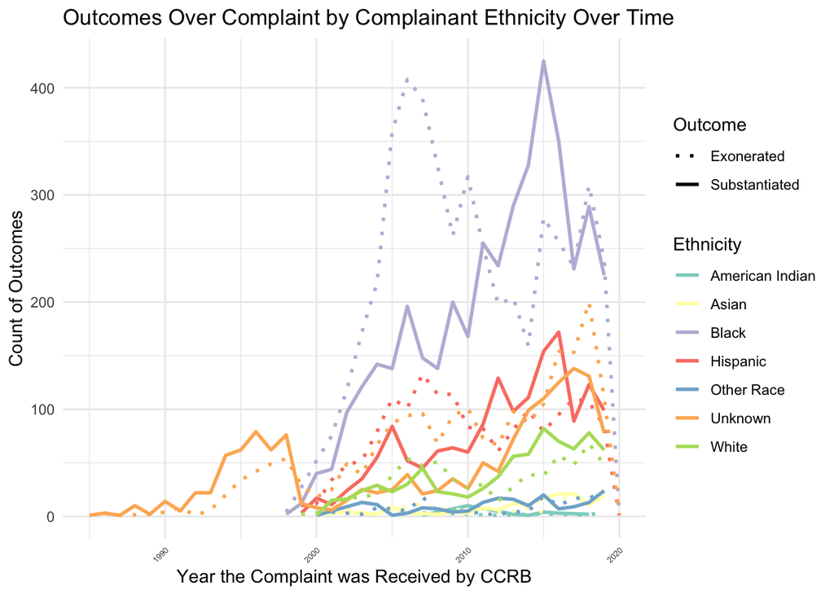

```r
ethnicity_year <- df.cleaned %>%
  group_by(year_received, complainant_ethnicity, outcome) %>%
  summarise(count = n(), .groups = "drop")

# Plot all covariates in 1 chart
ggplot(ethnicity_year, aes(x = year_received, y = count, color = complainant_ethnicity, linetype = as.factor(outcome))) +
  geom_line(size = 1) +
  labs(
    title = "Outcomes Over Complaint by Complainant Ethnicity Over Time",
    x = "Year the Complaint was Received by CCRB",
    y = "Count of Outcomes",
    color = "Ethnicity",
    linetype = "Outcome"
  ) +
  scale_color_manual(         # adjust the color scheme for different ethnicity groups to match with the overall color pattern
    values = c(
      "American Indian" = "#8DD3C7",
      "Asian" = "#FFFFB3",
      "Black" = "#BEBADA",
      "Hispanic" = "#FB8072",
      "Other Race" = "#80B1D3",
      "Unknown" = "#FDB462",
      "White" = "#B3DE69"
    )
  ) +
  scale_linetype_manual(
    values = c("0" = "dotted", "1" = "solid"),
    labels = c("0" = "Exonerated", "1" = "Substantiated")
  ) +
  theme_minimal() +
  theme(axis.text.x = element_text(angle = 45, hjust = 1, size = 5))
```

### Figure 10: Stacked Bar Plot - Distribution of Outcomes by Officers’ Gender

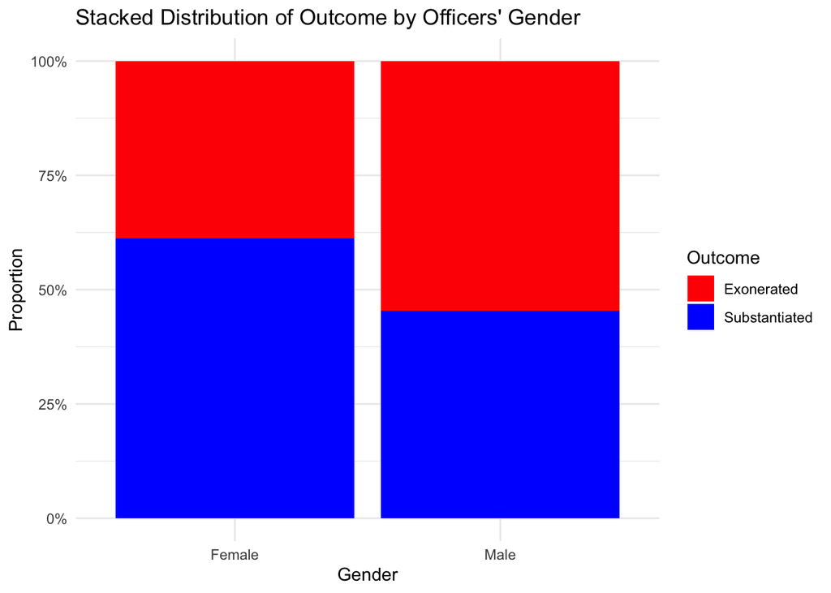

```r
stacked_bar_chart <- ggplot(df.cleaned, aes(x = mos_gender, fill = factor(outcome))) +
  geom_bar(position = "fill") +
  labs(title = "Stacked Distribution of Outcome by Officers' Gender",
       x = "Gender",
       y = "Proportion",
       fill = "Outcome") +
  scale_fill_manual(values = c("0" = "red", "1" = "blue"),
                    labels = c("0" = "Exonerated", "1" = "Substantiated")) +
  scale_y_continuous(labels = scales::percent) +
  theme_minimal()

print(stacked_bar_chart)
```

# Part III: Machine Learning Model

```r
ml_data <- df.cleaned
ml_data <- na.omit(ml_data)
ml_data$outcome <- as.factor(ml_data$outcome)

# Split the data into training and testing sets
set.seed(123)  # For reproducibility
trainIndex <- createDataPartition(ml_data$outcome, p = 0.8, list = FALSE)
trainData <- ml_data[trainIndex, ]
testData <- ml_data[-trainIndex, ]
```

*For the machine learning model, the covariates included in the model were chosen to capture critical dimensions influencing the outcomes. Temporal variables, such as month_received and year_received, provide insight into potential seasonal or annual trends in complaint handling, reflecting changes in policies or public scrutiny. The fado_type and allegation.cat variables represent the broader and specific categories of complaints, highlighting how the nature and severity of allegations impact substantiation likelihood. precinct_cat captures geographical and organizational context, recognizing that local factors or precinct-level practices may influence outcomes. Demographic variables, such as mos_gender (officer’s gender) and complainant_ethnicity (complainant’s ethnicity), allow for the exploration of potential biases or behavioral patterns in interactions and outcomes. Finally, outcome_desc.cat reflects the detailed disposition of cases, helping to understand how specific types of resolutions relate to substantiation probabilities. Together, these variables provide a comprehensive framework for analyzing the determinants of rulings.*

## Logistic Regression Model

```r
# GLM Model
glm_model <- glm(outcome ~ month_received + year_received + fado_type + precinct_cat+ allegation.cat + mos_gender +
                    complainant_ethnicity + outcome_desc.cat,
                 family = binomial(link = "logit"),
                 data = trainData)

# Summary of the GLM model
summary(glm_model)
```

```
##
## Call:
## glm(formula = outcome ~ month_received + year_received + fado_type +
##     precinct_cat + allegation.cat + mos_gender + complainant_ethnicity +
##     outcome_desc.cat, family = binomial(link = "logit"), data = trainData)
##
## Coefficients:
##                                                       Estimate Std. Error
## (Intercept)                                         -8.705e+01  8.620e+00
## month_received2                                     -1.257e-01  1.041e-01
## month_received3                                      1.110e-02  9.975e-02
## month_received4                                     -2.325e-01  1.035e-01
## month_received5                                     -1.292e-02  1.042e-01
## month_received6                                     -1.728e-01  1.039e-01
## month_received7                                     -2.734e-01  1.075e-01
## month_received8                                      7.087e-03  1.019e-01
## month_received9                                      6.988e-02  1.044e-01
## month_received10                                     3.912e-02  1.057e-01
## month_received11                                    -6.465e-02  1.090e-01
## month_received12                                     5.074e-02  1.113e-01
## year_received                                        4.526e-02  4.231e-03
## fado_typeDiscourtesy                                 1.517e-01  1.219e-01
## fado_typeForce                                      -2.354e+00  1.303e-01
## fado_typeOffensive Language                          1.559e+00  1.166e+00
## precinct_catBrooklyn                                -2.839e-01  5.682e-02
## precinct_catManhattan                               -8.894e-02  6.560e-02
## precinct_catQueens                                   4.907e-04  7.070e-02
## precinct_catStaten Island                           -4.097e-01  1.085e-01
## precinct_catUnknown                                 -6.924e-01  8.332e-01
## allegation.catHealth and Medical Issues              1.096e+00  1.541e+00
## allegation.catMisconduct                            -1.253e+00  1.178e+00
## allegation.catOther                                 -2.006e+00  1.165e+00
## allegation.catPolice Actions                        -3.351e+00  1.165e+00
## allegation.catProperty Damage                       -3.751e+00  1.165e+00
## allegation.catSearches and Seizures                 -3.104e+00  1.165e+00
## allegation.catThreats and Intimidation              -4.060e+00  1.166e+00
## allegation.catUse of Force                          -2.231e+00  1.170e+00
## mos_genderMale                                      -4.672e-01  9.085e-02
## complainant_ethnicityAsian                          -7.016e-01  4.225e-01
## complainant_ethnicityBlack                          -5.635e-01  3.967e-01
```

[output cut: 44 more lines]

```
## complainant_ethnicityWhite                           -1.385 0.166048
## outcome_desc.catArrests for Violent/Physical Crimes   2.468 0.013594 *
## outcome_desc.catJuvenile and Other Reports           19.636  < 2e-16 ***
## outcome_desc.catSummonses (Non-Arrest Related)        9.890  < 2e-16 ***
## outcome_desc.catUnknown                              -0.275 0.783476
## ---
## Signif. codes:  0 '***' 0.001 '**' 0.01 '*' 0.05 '.' 0.1 ' ' 1
##
## (Dispersion parameter for binomial family taken to be 1)
##
##     Null deviance: 16445  on 11884  degrees of freedom
## Residual deviance: 13155  on 11845  degrees of freedom
## AIC: 13235
##
## Number of Fisher Scoring iterations: 6
```

```r
# Predict on test data
glm_pred <- predict(glm_model, newdata = testData, type = "response")
glm_pred_class <- ifelse(glm_pred > 0.5, 1, 0)

# Evaluate GLM model
confusionMatrix(as.factor(glm_pred_class), as.factor(testData$outcome))
```

```
## Confusion Matrix and Statistics
##
##           Reference
## Prediction    0    1
##          0 1164  452
##          1  397  957
##
##                Accuracy : 0.7141
##                  95% CI : (0.6975, 0.7303)
##     No Information Rate : 0.5256
##     P-Value [Acc > NIR] : < 2e-16
##
##                   Kappa : 0.4257
##
##  Mcnemar's Test P-Value : 0.06384
##
##             Sensitivity : 0.7457
##             Specificity : 0.6792
##          Pos Pred Value : 0.7203
##          Neg Pred Value : 0.7068
##              Prevalence : 0.5256
##          Detection Rate : 0.3919
##    Detection Prevalence : 0.5441
##       Balanced Accuracy : 0.7124
##
##        'Positive' Class : 0
##
```

```r
# ROC and AUC for GLM
roc_glm <- roc(testData$outcome, glm_pred)
auc(roc_glm)
```

```
## Area under the curve: 0.7854
```

## Random Forest Model

```r
# Random Forest Model
rf_model <- randomForest(outcome ~ month_received + year_received + fado_type + precinct_cat+ allegation.cat +
                           mos_gender + complainant_ethnicity + outcome_desc.cat,
                         data = trainData, ntree = 500, importance = TRUE)
```

```r
# Summary of the Random Forest model
print(rf_model)
```

```
##
## Call:
##  randomForest(formula = outcome ~ month_received + year_received +      fado_type + precinct_cat + allegation.cat + mos_gender +      complainant_ethnicity + outcome_desc.cat, data = trainData,      ntree = 500, importance = TRUE)
##                Type of random forest: classification
##                      Number of trees: 500
## No. of variables tried at each split: 2
##
##         OOB estimate of  error rate: 24.31%
## Confusion matrix:
##      0    1 class.error
## 0 4804 1442   0.2308678
## 1 1447 4192   0.2566058
```

```r
summary(rf_model)
```

```
##                 Length Class  Mode
## call                5  -none- call
## type                1  -none- character
## predicted       11885  factor numeric
## err.rate         1500  -none- numeric
## confusion           6  -none- numeric
## votes           23770  matrix numeric
## oob.times       11885  -none- numeric
## classes             2  -none- character
## importance         32  -none- numeric
## importanceSD       24  -none- numeric
## localImportance     0  -none- NULL
## proximity           0  -none- NULL
## ntree               1  -none- numeric
## mtry                1  -none- numeric
## forest             14  -none- list
## y               11885  factor numeric
## test                0  -none- NULL
## inbag               0  -none- NULL
## terms               3  terms  call
```

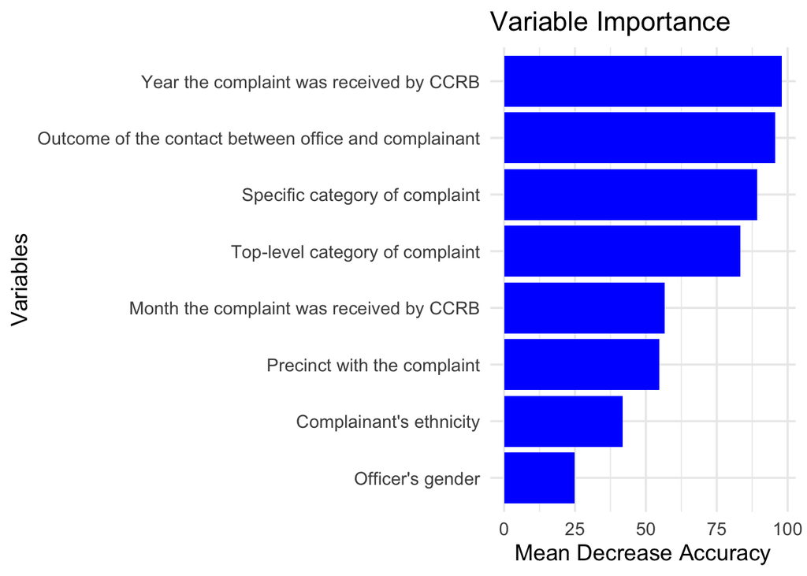

```r
# Extract variable importance from the Random Forest model
importance_df <- as.data.frame(importance(rf_model))
importance_df$Variable <- rownames(importance_df)  # Add variable names as a column

# Sort the data by Mean Decrease Accuracy
importance_df <- importance_df[order(importance_df$MeanDecreaseAccuracy, decreasing = TRUE), ]

# Create a named vector for the updated labels
variable_labels <- c(
  "month_received" = "Month the complaint was received by CCRB",
  "year_received" = "Year the complaint was received by CCRB",
  "outcome_desc.cat" = "Outcome of the contact between office and complainant",
  "allegation.cat" = "Specific category of complaint",
  "fado_type" = "Top-level category of complaint",
  "precinct_cat" = "Precinct with the complaint",
  "complainant_ethnicity" = "Complainant's ethnicity",
  "mos_gender" = "Officer's gender"
)

# Replace variable names with labels in the data frame
importance_df$Variable <- variable_labels[importance_df$Variable]

# Recreate the bar plot with updated y-axis labels
ggplot(importance_df, aes(x = reorder(Variable, MeanDecreaseAccuracy), y = MeanDecreaseAccuracy)) +
  geom_bar(stat = "identity", fill = "blue") +
  coord_flip() +  # Flip for horizontal bars
  theme_minimal(base_size = 14) +
  labs(title = "Variable Importance",
       x = "Variables",
       y = "Mean Decrease Accuracy")
```

```r
# Predict probabilities and classes on test data
rf_pred_prob <- predict(rf_model, newdata = testData, type = "prob")[, 2]
rf_pred_class <- predict(rf_model, newdata = testData)

# Evaluate Random Forest model
confusionMatrix(as.factor(rf_pred_class), testData$outcome)
```

```
## Confusion Matrix and Statistics
##
##           Reference
## Prediction    0    1
##          0 1210  375
##          1  351 1034
##
##                Accuracy : 0.7556
##                  95% CI : (0.7397, 0.7709)
##     No Information Rate : 0.5256
##     P-Value [Acc > NIR] : <2e-16
##
##                   Kappa : 0.5094
##
##  Mcnemar's Test P-Value : 0.3933
##
##             Sensitivity : 0.7751
##             Specificity : 0.7339
##          Pos Pred Value : 0.7634
##          Neg Pred Value : 0.7466
##              Prevalence : 0.5256
##          Detection Rate : 0.4074
##    Detection Prevalence : 0.5337
##       Balanced Accuracy : 0.7545
##
##        'Positive' Class : 0
##
```

```r
# ROC and AUC for RF
roc_rf <- roc(as.numeric(testData$outcome) - 1, rf_pred_prob)  # Convert factor to numeric for ROC
auc(roc_rf)
```

```
## Area under the curve: 0.8302
```

## Compare Logistic Regression Model and Random Forest Model

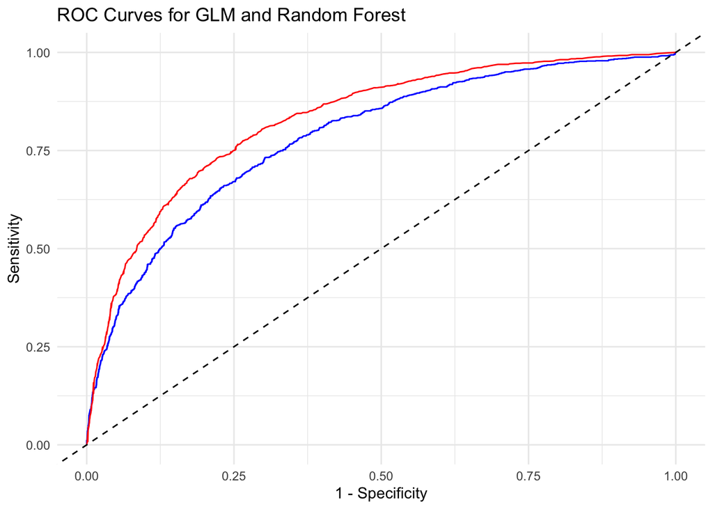

```r
# Plot ROC curves
# Assess classification performance
ggplot() +
  geom_line(data = data.frame(specificities = 1 - roc_glm$specificities, sensitivities = roc_glm$sensitivities),
            aes(x = specificities, y = sensitivities), color = "blue") +
  geom_line(data = data.frame(specificities = 1 - roc_rf$specificities, sensitivities = roc_rf$sensitivities),
            aes(x = specificities, y = sensitivities), color = "red") +
  geom_abline(linetype = "dashed", color = "black") +
  labs(title = "ROC Curves for GLM and Random Forest", x = "1 - Specificity", y = "Sensitivity") +
  theme_minimal() +
  scale_color_manual(name = "Model", values = c("blue" = "GLM", "red" = "RF"))
```

```r
# Calculate AUC for GLM
auc_glm <- auc(roc_glm)
cat("AUC for Logistic Regression (GLM):", round(auc_glm, 4), "\n")
```

```
## AUC for Logistic Regression (GLM): 0.7854
```

```r
# Calculate AUC for Random Forest
auc_rf <- auc(roc_rf)
cat("AUC for Random Forest:", round(auc_rf, 4), "\n")
```

```
## AUC for Random Forest: 0.8302
```

*Comparing the logistics regression model and the random forest model, the random forest has a higher accuracy(0.7556), sensitivity(0.7751), and specificity(0.7339) than the regression model (0.7141, 0.7457, 0.6792). This means that the random forest has a better ability to predict the true outcome. Furthermore, the AUC score also shows that the random forest model has a better performance (0.8302 > 0.7854).*